# chapter03_条形图

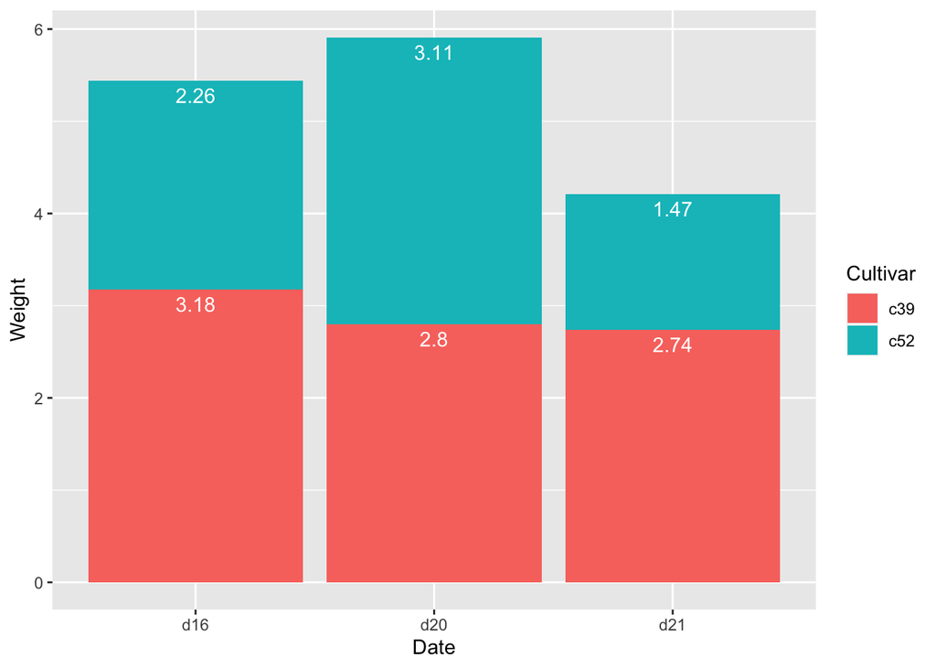

```r
> ggplot(ce,aes(x=Date,y=Weight,fill=Cultivar)) +
+   geom_bar(stat="identity",position = position_stack(reverse = TRUE)) +
+   geom_text(aes(y=label_y,label=Weight),vjust=1.5,colour="white")
```

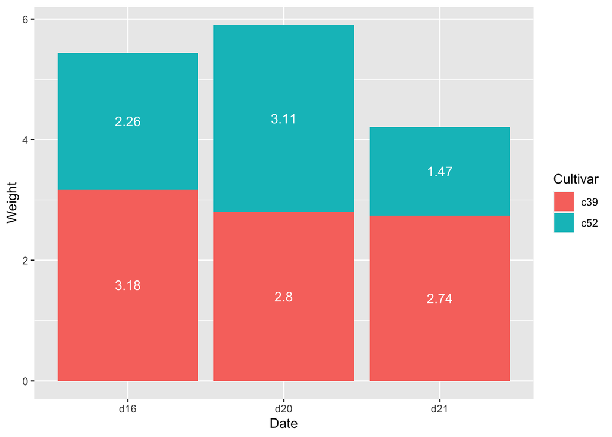

```r
> ce <- arrange(cabbage_exp,Date,Cultivar)
> # 计算y轴的位置，将数据标签置于条形中部
> ce <- ddply(ce,"Date",transform,label_y=cumsum(Weight)-0.5*Weight)
> ggplot(ce,aes(x=Date,y=Weight,fill=Cultivar)) +
+   geom_bar(stat="identity",position = position_stack(reverse = TRUE)) +
+   geom_text(aes(y=label_y,label=Weight),colour="White")
```

- 为了得到效果更好的条形图，我们修改一下图例顺序和颜色，将数据标签置于条形中间，同时通过字号参数(size)缩小标签字号，并调用paste函数在标签后面添加“kg”，为了使得标签保留两位小数我们还需调用format函数：

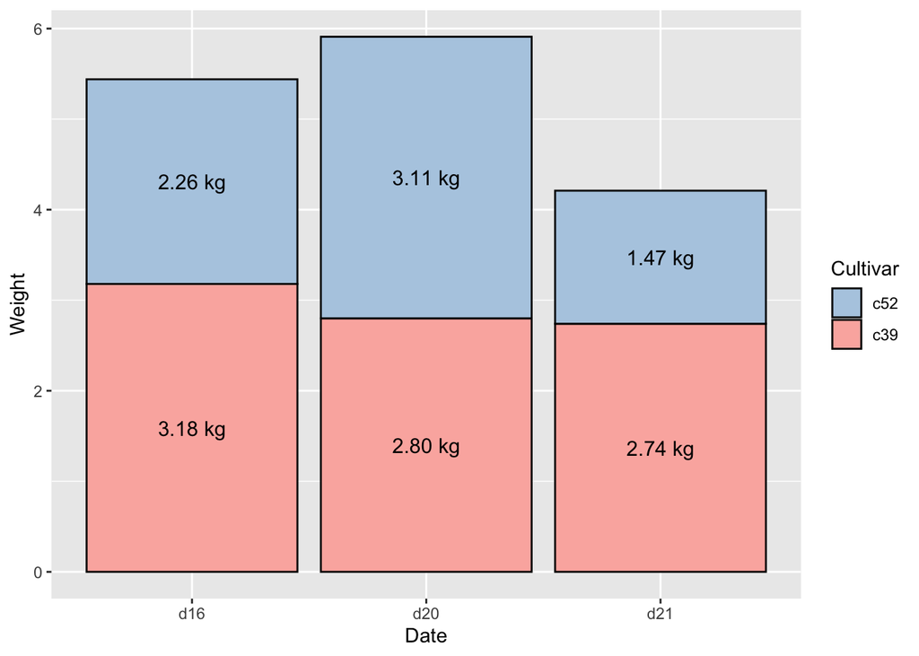

```r
> ggplot(ce,aes(x=Date,y=Weight,fill=Cultivar)) +
+   geom_bar(stat="identity",colour="black",position = position_stack(reverse = TRUE)) +
+   geom_text(aes(y=label_y,label=paste(format(Weight,nsmall=2),"kg")),size=4) +
+   guides(fill=guide_legend(reverse=TRUE)) +
+   scale_fill_brewer(palette="Pastel1")
```

- 更多关于控制文本格式的内容可参见9.2节。
- 更多关于分组转换数据的内容可参见15.6节。

## 3.10 绘制Cleveland点图

- 有时人们会用Cleverland点图来替代条形图以减少图形造成的视觉混乱并使图形更具可读性。最简便的绘制Cleverland点图的方法是直接运行`geom_point()`命令：

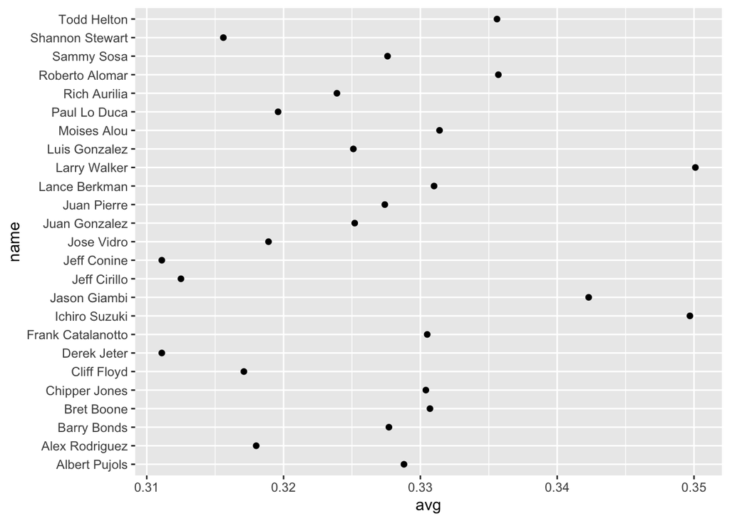

```r
> library(gcookbook) #为了使用数据
> tophit <- tophitters2001[1:25,] #取出tophitters数据集中的前25个数据
> ggplot(tophit,aes(x=avg,y=name)) + geom_point()
```

```r
> tophit6 <- tophit[,c("name","lg","avg")]
> head(tophit6)
            name lg    avg
1   Larry Walker NL 0.3501
2  Ichiro Suzuki AL 0.3497
3   Jason Giambi AL 0.3423
4 Roberto Alomar AL 0.3357
5    Todd Helton NL 0.3356
6    Moises Alou NL 0.3314
```

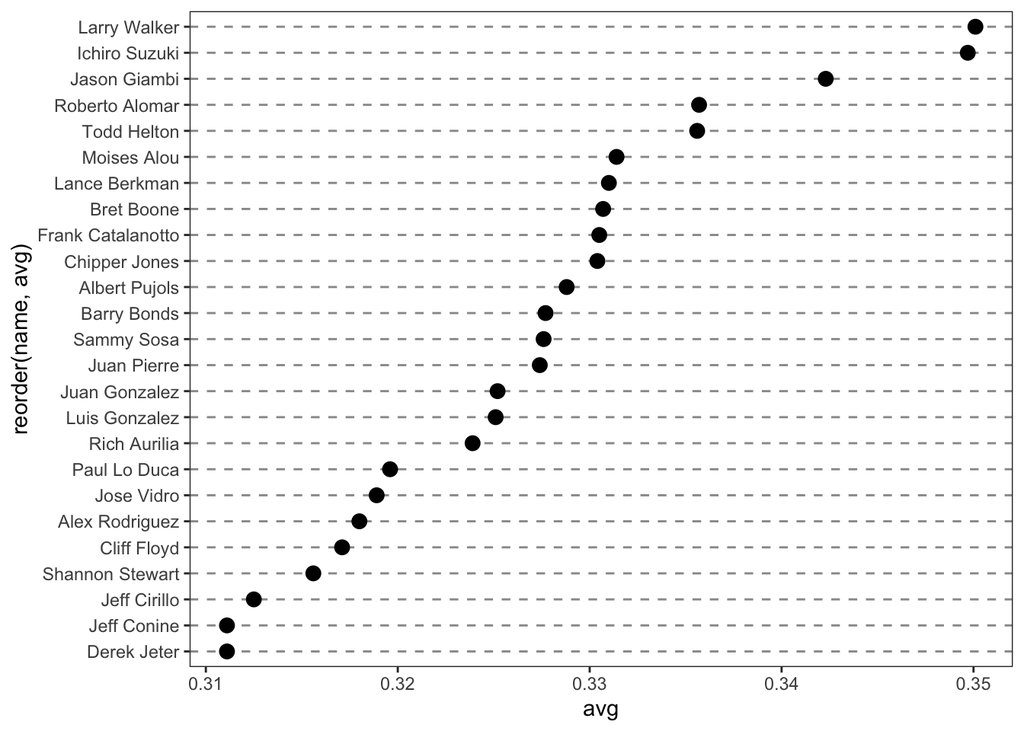

```r
> ggplot(tophit,aes(x=avg,y=reorder(name,avg))) +
+   geom_point(size=3) + #使用更大的点
+   theme_bw() +
+   theme(panel.grid.major.x=element_blank(),
+         panel.grid.minor.x=element_blank(),
+         panel.grid.major.y=element_line(colour="grey60",linetype="dashed"))
```

- 我们也可以将点图的x轴和y轴互换，互换后，x轴对应于姓名，y轴将对应于数值，如下图所示。我们也可以将数据标签旋转60”。

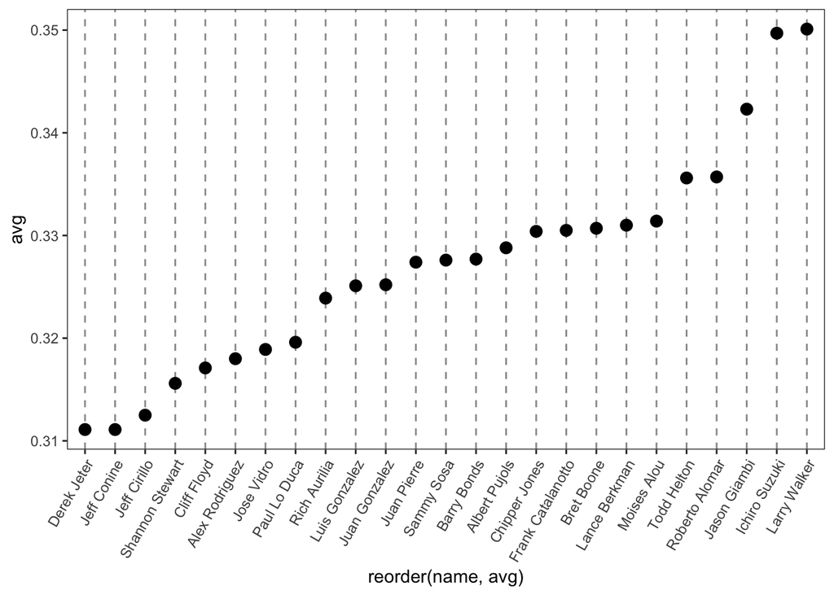

```r
> ggplot(tophit, aes (x=reorder(name, avg), y=avg)) +
+   geom_point(size=3) + # 使用更大的点
+   theme_bw() +
+   theme(axis.text.x = element_text(angle=60, hjust=1),
+         panel.grid.major.y = element_blank(),
+         panel.grid.minor.y = element_blank(),
+         panel.grid.major.x = element_line(colour="grey60", linetype="dashed"))
```

- 有时候，根据其他变量对样本进行分组很有用。这里我们根据因子lg对样本进行分组，因子lg对应有NL和AL两个水平，分别表示国家队(National League)和美国队 (American league)。我们依次根据lg和avg对变量进行排序。遗憾的是，`reorder()`函数只能根据一个变量对因子水平进行排序，所以我们只能手动实现上述过程。绘制点图时(见下图)，我们把lg变量映射到点的颜色属性上。借助`geom_segment()`函数用“以数据点为端点的线段”代替贯通全图的网格线。注意`geom_segment()`函数需要设定x、y、xend和yend四个参数：

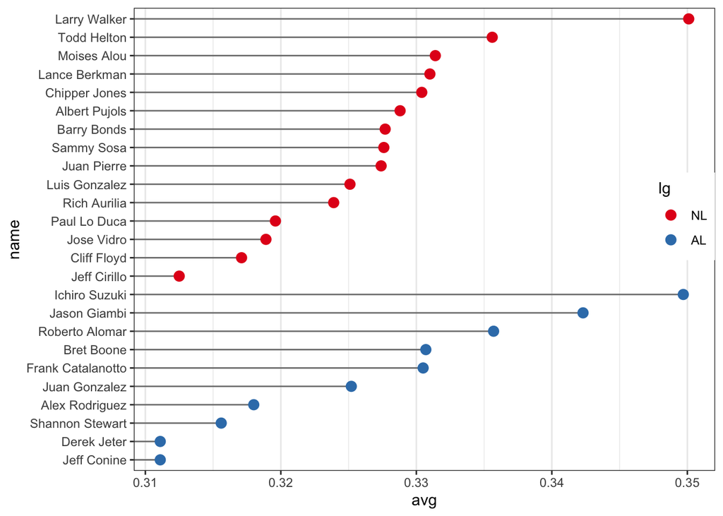

```r
> # 提取出name变量，依次根据变量lg和avg对其进行排序
> nameorder <- tophit$name[order(tophit$lg, tophit$avg)]
> #将name转化为因子，因子水平与nameorder一致
> tophit$name <- factor(tophit$name, levels=nameorder)
> ggplot(tophit, aes(x=avg, y=name)) +
+   geom_segment(aes(yend=name), xend=0, colour="grey50") +
+   geom_point(size=3, aes(colour=lg)) +
+   scale_colour_brewer(palette="Set1", limits=c("NL","AL")) +
+   theme_bw() +
+   theme(panel.grid.major.y = element_blank(),  # 删除水平网格线
+         legend.position=c(1, 0.55),  # 将图例放置在绘图区域中
+         legend.justification=c(1, 0.5))
```

- 另外一种分组展示数据的方式是分面，如下图所示。分面条形图中的条形的堆叠顺序与上图中的堆叠顺序有所不同；要修改分面显示的堆叠顺序只有通过调整lg变量的因子水平来实现。

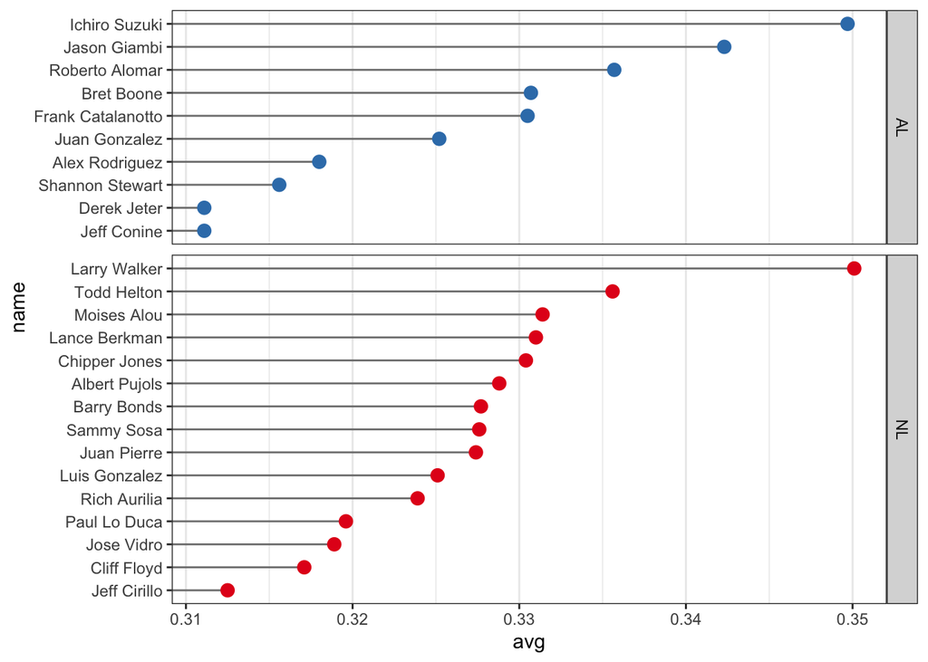

```r
> ggplot(tophit, aes(x=avg, y=name)) +
+   geom_segment(aes(yend=name), xend=0, colour="grey50") +
+   geom_point(size=3, aes(colour=lg)) +
+   scale_colour_brewer(palette="Set1", limits=c("NL","AL"), guide = "none") +
+   theme_bw() +
+   theme(panel.grid.major.y = element_blank()) +
+   facet_grid(lg ~ ., scales="free_y", space="free_y")
```

- 上图以队为分组变量进行分面绘图。
- 更多关于调整因子水平顺序的内容可参见15.8节。关于基于其他变量调整因子水平顺序的细节内容可参见15.9节。
- 更多关于调整图例位置的内容可参见10.2节。更多关于隐藏网格线的内容，可参见9.6节。